# Example RNA-seq Report: Differences between Breast and Colon Tissue

Example analysis steps/calculations and visualizations for RNA sequencing (RNA-seq) analysis.

## Read / Wrangle Files

### Read Files in Recursively

```r
# get list of files
list.files(path = 'count_tables',
           pattern = 'counts.txt',
           full.names = T) -> files

# Read files in recursively
vroom(file = files, id = 'file_path', delim = '\t', comment = '#', skip = 2,
      col_names = c('ensembl_gene_id', 'chr', 'start', 'end',
                    'strand', 'length', 'count')) %>%
  mutate(sample_id = str_extract(file_path, 'ENCFF[0-9,A-Z]{6}'),
         tissue = ifelse(str_detect(file_path, 'breast'),
                            'breast', 'colon')) %>%
  dplyr::select(-file_path) -> data
```

```
## Rows: 406,357
## Columns: 8
## chr [5]: ensembl_gene_id, chr, start, end, strand
## dbl [2]: length, count
##
## Pass a specification to the `col_types` argument to quiet this message
```

### Wrangle Data for `DESeq2`

Transform the data into a count matrix and an annotation table.

```r
data %>%
  dplyr::select(ensembl_gene_id, sample_id, count) %>%
  pivot_wider(names_from = sample_id, values_from = count) %>%
  as.data.frame() -> count_matrix

data %>%
  dplyr::select(sample_id, tissue) %>%
  distinct() -> metadata
```

#### Convert to DESeq2 DESeqDataSet Object

```r
dds <- DESeqDataSetFromMatrix(countData = count_matrix,
                              colData = metadata,
                              tidy = TRUE,
                              design = ~ tissue)
```

#### Pre-filter the dataset

Remove rows that contain only zero counts. There’s no point in testing genes where nothing was detected.

```r
### filter out rows that contain only zero counts
keep <- rowSums(counts(dds)) > 1
dds <- dds[keep, ]
```

## Check Quality by Examing the Associations Between Samples

### PCA

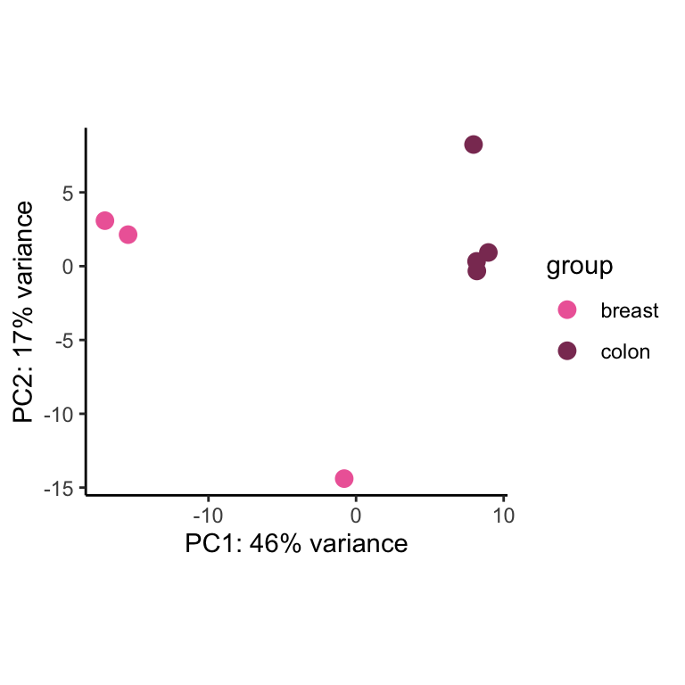

```r
# normalize the counts
vsd <- varianceStabilizingTransformation(dds, blind = FALSE)

# plot the PCa
plotPCA(vsd, intgroup = 'tissue') +
  geom_point() +
  scale_color_manual(values = c('hotpink2', 'hotpink4')) +
  theme_classic()
```

## Differential Expression

### Calculate differential expression

```r
dds <- DESeq(dds)
```

### Wrangle and Save the Results

Get human readable gene names

```r
# check which annotations are available.
columns(org.Hs.eg.db)
```

```
##  [1] "ACCNUM"       "ALIAS"        "ENSEMBL"      "ENSEMBLPROT"  "ENSEMBLTRANS"
##  [6] "ENTREZID"     "ENZYME"       "EVIDENCE"     "EVIDENCEALL"  "GENENAME"
## [11] "GO"           "GOALL"        "IPI"          "MAP"          "OMIM"
## [16] "ONTOLOGY"     "ONTOLOGYALL"  "PATH"         "PFAM"         "PMID"
## [21] "PROSITE"      "REFSEQ"       "SYMBOL"       "UCSCKG"       "UNIGENE"
## [26] "UNIPROT"
```

```r
# use the Ensembl IDs to find the corresponding HGNC IDs
mapIds(org.Hs.eg.db,
       keys = rownames(results(dds)),
       column = 'SYMBOL',
       keytype = 'ENSEMBL',
       multiVals = 'first') %>%
  enframe(name = 'ensembl_gene_id', value = 'gene') -> gene_names
```

Wrangle the differential expression result object to get a rectangular table with the human readable gene IDs.

```r
results(dds) %>%
  as.data.frame() %>%
  rownames_to_column('ensembl_gene_id') %>%
  left_join(gene_names, by = 'ensembl_gene_id') %>%
  dplyr::select(gene, ensembl_gene_id, everything()) %>%
  mutate(sig = ifelse(padj < 0.05 & abs(log2FoldChange) >= 1,
                      'sig', 'notsig'),
         log_qvalue = -log10(padj)) %>%
  replace_na(list(sig = 'notsig', log_qvalue = 0)) -> diff_exp_tbl
```

Save the results of the differential expression test.

```r
# write_tsv(diff_exp_tbl, 'diff_exp.tsv')
```

## Visualize Results

### MA Plot

Only a few genes are differentially expressed, many of them with originally low counts.

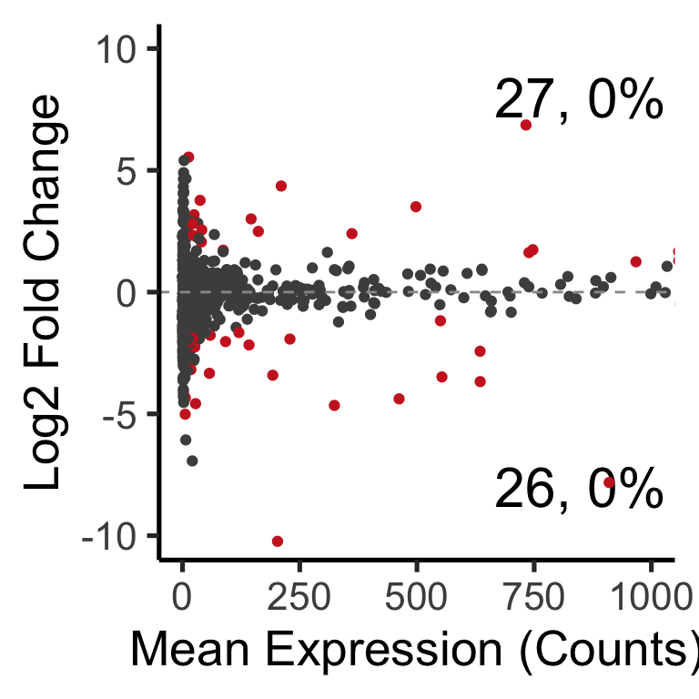

```r
diff_exp_tbl %>%
  mutate(direction = ifelse(log2FoldChange < 0, 'down', 'up')) %>%
  group_by(direction, sig) %>%
  dplyr::count() %>%
  ungroup() %>%
  filter(sig == 'sig') %>%
  mutate(label = paste0(n, ', ', round((n / nrow(diff_exp_tbl)), 1), '%'),
         baseMean = 850,
         log2FoldChange = c(-8, 8)) -> ma_labels

# plot
ggplot(diff_exp_tbl, aes(x = baseMean, y = log2FoldChange)) +
  geom_text(data = ma_labels, aes(label = label), size = 8) +
  geom_point(aes(color = sig)) +
  scale_color_manual(values = c('gray30', 'firebrick3')) +
  geom_hline(yintercept = 0, color = 'gray60', linetype = 'dashed') +
  labs(x = 'Mean Expression (Counts)', y = 'Log2 Fold Change') +
  coord_cartesian(xlim = c(0, 1000), ylim = c(-10, 10)) +
  theme_classic(base_size = 20) +
  theme(legend.position = 'none')
```

### Volcano Plot

Only a few up- and down-regulated genes.

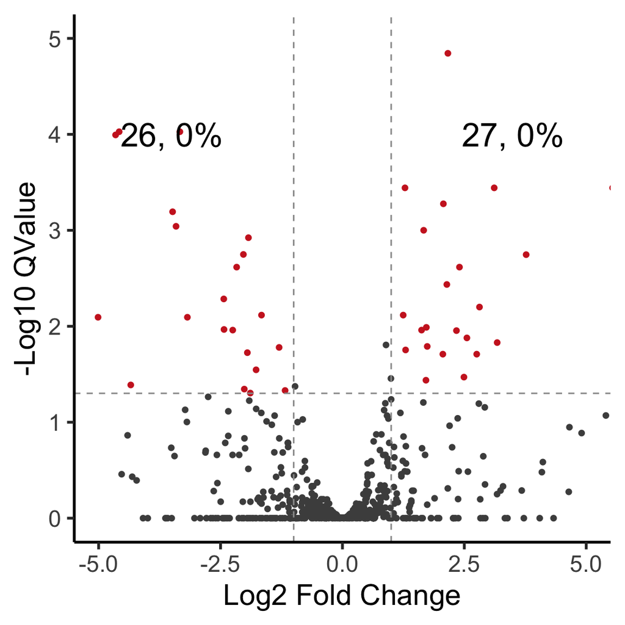

```r
# Create labels for the number and percentage of significantly up- and down-
# regulated genes
diff_exp_tbl %>%
  mutate(direction = ifelse(log2FoldChange < 0, 'down', 'up')) %>%
  group_by(direction, sig) %>%
  dplyr::count() %>%
  ungroup() %>%
  # complete(direction, sig, fill = list(n = 0)) %>%
  # na.omit() %>%
  filter(sig == 'sig') %>%
  mutate(label = paste0(n, ', ', round((n / nrow(diff_exp_tbl)), 1), '%'),
         log2FoldChange = c(-3.5, 3.5),
         log_qvalue = 4) -> volc_labels

# plot
ggplot(diff_exp_tbl, aes(x = log2FoldChange, y = log_qvalue)) +
  geom_point(aes(color = sig)) +
  scale_color_manual(values = c('gray30', 'firebrick3')) +
  geom_hline(yintercept = -log10(0.05), color = 'gray60', linetype = 'dashed') +
  geom_vline(xintercept = c(-1, 1), color = 'gray60', linetype = 'dashed') +
  geom_text(data = volc_labels, aes(label = label), size = 8) +
  labs(x = 'Log2 Fold Change', y = '-Log10 QValue') +
  coord_cartesian(xlim = c(-5, 5), ylim = c(0, 5)) +
  theme_classic(base_size = 20) +
  theme(legend.position = 'none')
```

## Pathway Analysis

### Wrangle Differential Expression Data for Pathway Analysis

Get the list of Entrez IDs that correspond to all our genes detected in the differential expression analysis.

```r
# get Entrez IDs from our Ensembl IDs for fgsea()
AnnotationDbi::mapIds(org.Hs.eg.db,
                      keys = unique(diff_exp_tbl$ensembl_gene_id),
                      keytype = 'ENSEMBL',
                      column = 'ENTREZID',
                      multiVals = 'first') %>%
  enframe(name = 'gene', value = 'entrez_id') %>%
  unnest(c(entrez_id)) -> entrez_ids
# make a named vector of our genes for fgsea()
diff_exp_tbl %>%
  dplyr::select(ensembl_gene_id, stat) %>%
  left_join(entrez_ids, by = c('ensembl_gene_id' = 'gene')) %>%
  dplyr::select(entrez_id, stat) %>%
  deframe() -> diff_exp_res
```

### Calculate Pathway Analysis

Load the Reactome pathways

```r
# use Reactome pathwayse
reactome_pathways <- reactomePathways(names(exampleRanks))
```

Run the pathway analysis

```r
fgsea_res <- fgsea(pathways = reactome_pathways,
                   stats = exampleRanks,
                   nperm = 1000)
```

Save results

```r
### save results
fgsea_res %>%
  unnest(c(leadingEdge)) #%>%
```

```
## # A tibble: 17,134 x 8
##    pathway               pval  padj     ES    NES nMoreExtreme  size leadingEdge
##    <chr>                <dbl> <dbl>  <dbl>  <dbl>        <dbl> <int> <chr>
##  1 5-Phosphoribose 1-d… 0.878 0.955  0.427  0.679          444     2 328099
##  2 5-Phosphoribose 1-d… 0.878 0.955  0.427  0.679          444     2 19139
##  3 A tetrasaccharide l… 0.702 0.889  0.322  0.825          406    11 14733
##  4 A tetrasaccharide l… 0.702 0.889  0.322  0.825          406    11 20971
##  5 A tetrasaccharide l… 0.702 0.889  0.322  0.825          406    11 20970
##  6 A tetrasaccharide l… 0.702 0.889  0.322  0.825          406    11 12032
##  7 A tetrasaccharide l… 0.702 0.889  0.322  0.825          406    11 29873
##  8 A tetrasaccharide l… 0.702 0.889  0.322  0.825          406    11 218271
##  9 A tetrasaccharide l… 0.702 0.889  0.322  0.825          406    11 13179
## 10 Abacavir metabolism  0.362 0.730 -0.628 -1.13           173     3 11522
## # … with 17,124 more rows
```

```r
  # write_tsv('all_pathway_results.tsv')

### save collapsed results
# find the essential top-level pathways
collapsed_pathways <- collapsePathways(fgsea_res,
                                       pathways = reactome_pathways,
                                       stats = exampleRanks)

# filter the results for the essential pathways
fgsea_res %>%
  filter(pathway %in% collapsed_pathways$mainPathways) %>%
  arrange(pathway) %>%
  unnest(c(leadingEdge)) #%>%
```

```
## # A tibble: 1,517 x 8
##    pathway               pval   padj     ES   NES nMoreExtreme  size leadingEdge
##    <chr>                <dbl>  <dbl>  <dbl> <dbl>        <dbl> <int> <chr>
##  1 Activated NOTCH1 … 0.00673 0.0680 -0.763 -1.82            2     7 14357
##  2 Activated NOTCH1 … 0.00673 0.0680 -0.763 -1.82            2     7 18128
##  3 Activated NOTCH1 … 0.00673 0.0680 -0.763 -1.82            2     7 74198
##  4 Activation of IRF… 0.0145  0.112  -0.655 -1.76            5    10 56489
##  5 Activation of IRF… 0.0145  0.112  -0.655 -1.76            5    10 54131
##  6 Activation of IRF… 0.0145  0.112  -0.655 -1.76            5    10 54123
##  7 Activation of IRF… 0.0145  0.112  -0.655 -1.76            5    10 56480
##  8 Activation of IRF… 0.0145  0.112  -0.655 -1.76            5    10 22031
##  9 Apoptosis          0.00147 0.0310  0.516  2.04            0    71 58801
## 10 Apoptosis          0.00147 0.0310  0.516  2.04            0    71 14958
## # … with 1,507 more rows
```

```r
  # write_tsv('top_level_pathway_results.tsv')
```

#### Visualize

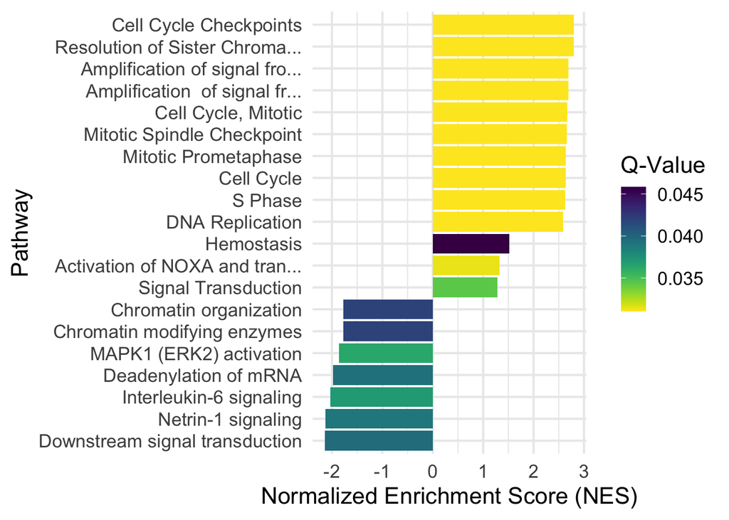

```r
fgsea_res %>% #arrange(desc(nchar(pathway)))
# filter for significant pathways
  filter(padj < 0.05) %>%
# arrange by the normalized enrichment score
  arrange(NES) %>%
# get the first and last 10 rows which will be the 10 most up- and down-
# regulated pathways
  do(rbind(head(., 10), tail(., 10))) %>%
# the pathway names can be long, so if they're over 20 characters, subset them
# otherwise use the whole name
  mutate(pathway_short = ifelse(nchar(pathway) <= 30,
                                pathway,
                                paste0(str_sub(pathway, start = 1, end = 27),
                                       '...'))) %>%

ggplot(aes(x = reorder(pathway_short, NES), y = NES)) +
  geom_col(aes(fill = padj)) +
  scale_fill_viridis(direction = -1) +
  coord_flip() +
  labs(x = 'Pathway',
       y = 'Normalized Enrichment Score (NES)',
       fill = 'Q-Value') +
  theme_minimal(base_size = 16)
```